# Repression

## Repression

> … actual or threatened use of physical sanctions against an individual or organization, within the territorial jurisdiction of the state, for the purpose of imposing a cost on the target as well as deterring specific activities and/or beliefs perceived to be challenging to government personnel, practices or institutions

— Christian Davenport “State Repression and Political Order”

Repressive tactics:

- Violations of 1A-type rights
- Surveillance
- Detention
- Torture and mass killing

## How repression works: sheer attrition

- Arresting/killing/disabling supporters and potential supporters
- Targeted removal
- Targeting donors, freezing bank accounts, sanctions

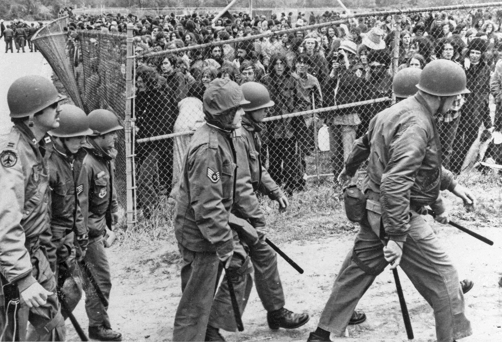

Military troops guarding anti-war protesters in a makeshift prison in RFK stadium (1971)

## How repression works: costs and deterrence

- Fear of arrest or other physical, social, or financial penalties.
- Raising the expectation that others will free ride

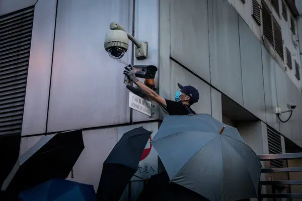

Protester disabling a surveillance camera in Hong Kong

## How repression works: disunity

- Infiltration, spying and coerced cooperation
- Conflicts over tactics and leadership

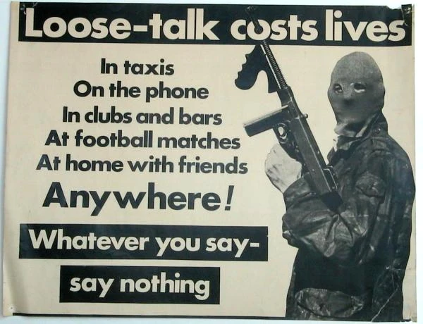

Irish Republican Army poster (circa 1970)

## How repression works: morale and expectations of the future

- Signalling that the government is strong
- Difficulty gauging public support

[figure not shown]

Police attacking environmental activists in Germany

## Repression and dissent

But does repression work? … It depends!

> … Scholars have theorized that all possible curves fit the impact of repression and dissent

— Mark Lichbach

## Repression decreasing dissent

- Extensive repression of Ogoni activists in Nigeria, culminating in the execution of protest leader Ken Saro-Wiwa in 1995.
- Ogoni movement demobilized (even after democratization in 1999)

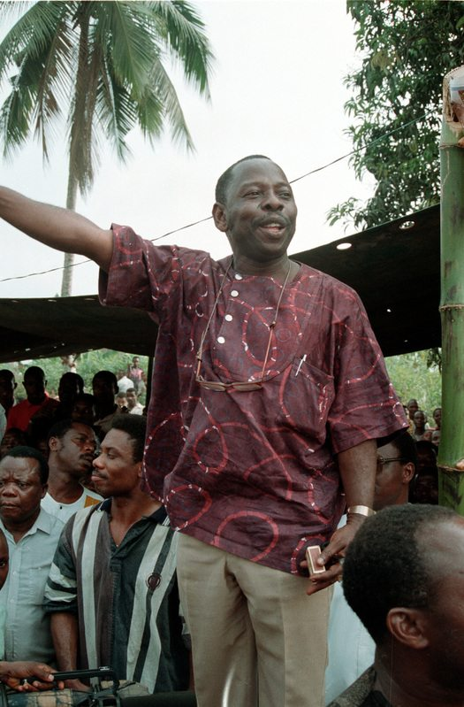

Ogoni Activist Ken Saro-Wiwa

## Repression increasing dissent

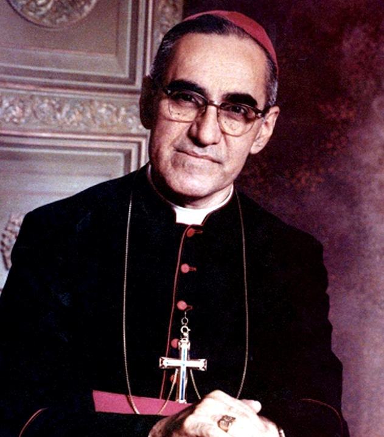

El Salvadoran Archbishop Oscar Romero

- Violent repression of left-wing movements in El Salvador in the 70s. The Archbishop and activist Oscar Romero killed during a Mass in 1980
- 8 months later: guerrilla groups unify to found the FMLN and conflict moves into full-blown civil war.

## Conditional effects of repression

- Intuitively, repression should decrease dissent, but sometimes it fails.
- So why does repression fail?

### A caution about counterfactuals

- Underwhelming but plausible explanation: repressed movements would have succeeded regardless.
- Difficult to entirely rule out because:
  - We don’t have true counterfactuals
  - Repression/Dissent are mutual causes.

### Substitution effects

Repression incentivizes a new mixture of tactics<sup>1</sup>

- Opposition want to maintain a constant level of “pressure” by selecting an optimum mixture of violent and non-violent tactics.
- If states raise the costs of using the more efficient tactic, then opposition groups will sometimes compensate by using more of a relatively less efficient tactic.
- In some circumstances, raising the costs of a tactic might lead to more use of the tactic itself.<sup>2</sup>
[^1]: See: Lichbach (1987)
[^2]: Heath et al. (2000)

### Public opinion and targeting

Repression also has costs for governments, and those costs are variable.

- Public support/opposition for repression depends on both protesters and govt tactics.
- Violent repression of non-violent movements is particularly likely to elicit greater public opposition.
- Repression of “out-groups” is more likely to be supported than repression of in-groups.<sup>1</sup>

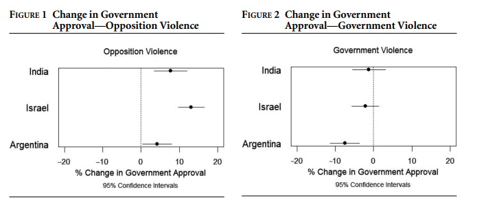

Lupu and Wallace (2019)

[^3]: Edwards and Arnon (2021)

### Micromobilization

Repression raises costs but triggers micromobilization processes that encourage more protest. For instance:

- Being arrested for protest might shut you out of non-protest social circles
- Martyrdom and prestige among activists
- Increasing the expectation that “important others” will participate

### Micromobilization and social networks

- One implication: these effects depend on whether you’re already embedded in a network of protest supporters.

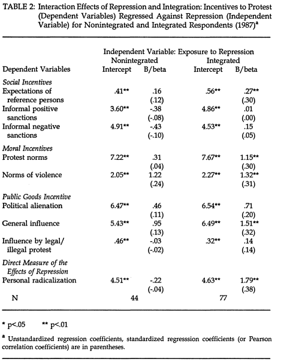

Opp and Roehl (1990)

### Micromobilization and timing

- Costs are immediate, but micromobilization takes time
- So: repression will have short term negative effects but long term positive effects.

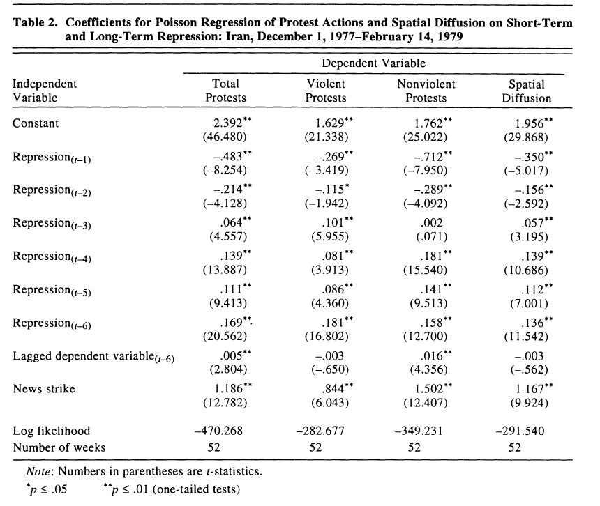

Rasler (1996)

### Indiscriminate repression

- *Indiscriminate* repression doesn’t actually change the relative costs of protesting, but it can increase the perceived benefits of regime change (targeted repression is hard, especially for weak states!)

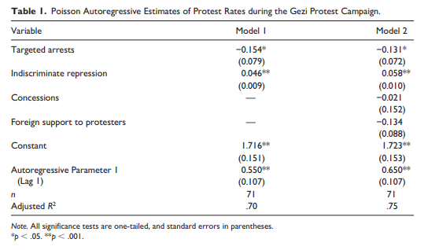

Demirel-Pegg and Rasler (2021)

### References

Demirel-Pegg, Tijen, and Karen Rasler. 2021. “The Effects of Selective and Indiscriminate Repression on the 2013 Gezi Park Nonviolent Resistance Campaign.” *Sociological Perspectives* 64 (1): 58–81.

Edwards, Pearce, and Daniel Arnon. 2021. “Violence on Many Sides: Framing Effects on Protest and Support for Repression.” *British Journal of Political Science* 51 (2): 488–506.

Heath, Julia A, T David Mason, William T Smith, and Joseph P Weingarten. 2000. “The Calculus of Fear: Revolution, Repression, and the Rational Peasant.” *Social Science Quarterly*, 622–33.

Lichbach, Mark Irving. 1987. “Deterrence or Escalation? The Puzzle of Aggregate Studies of Repression and Dissent.” *Journal of Conflict Resolution* 31 (2): 266–97.

Lupu, Yonatan, and Geoffrey PR Wallace. 2019. “Violence, Nonviolence, and the Effects of International Human Rights Law.” *American Journal of Political Science* 63 (2): 411–26.

Opp, Karl-Dieter, and Wolfgang Roehl. 1990. “Repression, Micromobilization, and Political Protest.” *Social Forces* 69 (2): 521–47.

Rasler, Karen. 1996. “Concessions, Repression, and Political Protest in the Iranian Revolution.” *American Sociological Review*, 132–52.

[figure not shown]